# TidyModels: modeltime

UPDATE: 2022-12-24 03:33:21

# はじめに

`tidymodels`パッケージの使い方をいくつかのノートに分けてまとめている。`tidymodels`パッケージは、統計モデルや機械学習モデルを構築するために必要なパッケージをコレクションしているパッケージで、非常に色んなパッケージがある。ここでは、今回は`modeltime`パッケージについてまとめていく。モデルの数理的な側面や機械学習の用語などは、このノートでは扱わない。

下記の公式ドキュメントや`tidymodels`パッケージに関する書籍を参考にしている。

- [Tidymodels](https://www.tidymodels.org/)
- [Tidy Modeling with R](https://www.tmwr.org/software-modeling.html)

## `modeltime`パッケージの目的

`modeltime`パッケージは、時系列モデルの構築を効率よく行うためのパッケージで、`tidymodels`パッケージと組み合わせて時系列モデルを作成する際に使用される。時系列予測のための体系的なワークフローを提供し、時系列ブーストモデルなど新しいアルゴリズムもカバーしている点が特徴的。

- [modeltime](https://business-science.github.io/modeltime/articles/getting-started-with-modeltime.html#step-2---create-fit-multiple-models)

上記のサイトをなぞりながら、不明点を追記しながらまとめていく。

## モデルの作成

まずは必要なパッケージを読み込んでおく。

```r
library(tidymodels)
library(modeltime)
library(tidyverse)
library(lubridate)
library(timetk)
```

`modeltime`パッケージの基本的なワークフローは下記の通り。丸括弧内には作業と対応する関数名を表示している。

- データを学習データ、テストデータに分割
- 複数のモデルを作成してフィッティング。そして、モデルテーブルに追加(`modeltime_table`関数)
- モデルをテストデータに合わせて調整(`modeltime_calibrate`関数)
- テストセットの予測と精度評価を行なう(`modeltime_forecast`関数、`modeltime_accuracy`関数)
- モデルをフルデータで再学習(`modeltime_refit`関数)
- 将来予測を行う(`modeltime_forecast`関数)

ここで利用するデータは`timetk`パッケージ内の`m4_monthly`データセットで、コンペティションで使用されたデータ。ここでは`id`が`M750`の部分を使用する。

データは、1990-01-01から始まり、2015-06-01まである。レコード数は306レコードで、間隔は月単位のデータになっている。

```r
m750 <- m4_monthly %>% filter(id == "M750")
m750 %>%
  summarise(start_date = min(date), end_date = max(date), records = n())
```

```
## # A tibble: 1 × 3
##   start_date end_date   records
##   <date>     <date>       <int>
## 1 1990-01-01 2015-06-01     306
```

`timetk`パッケージには、`plot_time_series`関数が用意されており、時系列データ簡単に可視化できる。そのため、`ggplot2`パッケージの関数を分析者が記述する必要がない。引数は沢山用意されており、グラフを柔軟にカスタマイズできる。

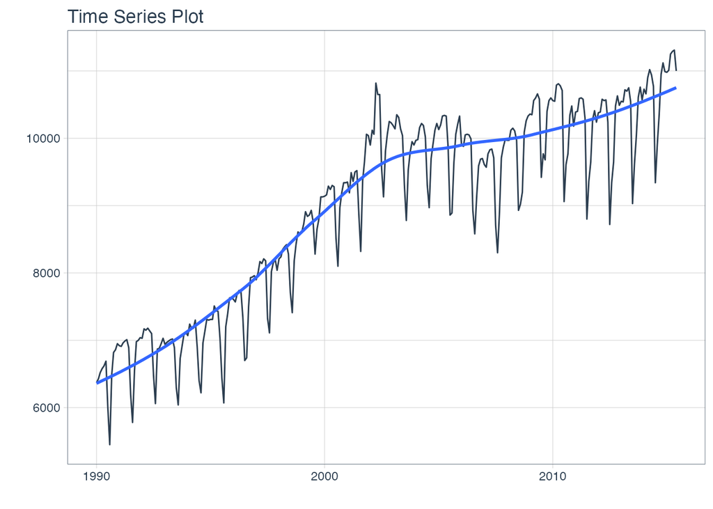

```r
m750 %>%
  plot_time_series(.data = ., .date_var = date, .value = value, .interactive = FALSE)
```

モデルを構築する前に、データを分割しておく。クロスバリデーションなどは次回のノートで扱うのでは、ここではシンプルに時系列データを分割する。`rsplit`クラスの分割データは、`tk_time_series_cv_plan`関数でデータフレームに変換できる。

今回は学習データが、1990-01-01から2012-11-01(22年10ヶ月)で、テストデータが2012-12-01から2015-06-01(2年6ヶ月)である。

```r
splits <- initial_time_split(m750, prop = 0.9)
df_train <- splits %>% training()
df_test <- splits %>% testing()

bind_rows(
  df_train %>% summarise(start_date = min(date), end_date = max(date), records = n()),
  df_test %>% summarise(start_date = min(date), end_date = max(date), records = n())
)
```

```
## # A tibble: 2 × 3
##   start_date end_date   records
##   <date>     <date>       <int>
## 1 1990-01-01 2012-11-01     275
## 2 2012-12-01 2015-06-01      31
```

そのまま`plot_time_series_cv_plan`関数に渡すことで、分割データの状態を可視化できる。

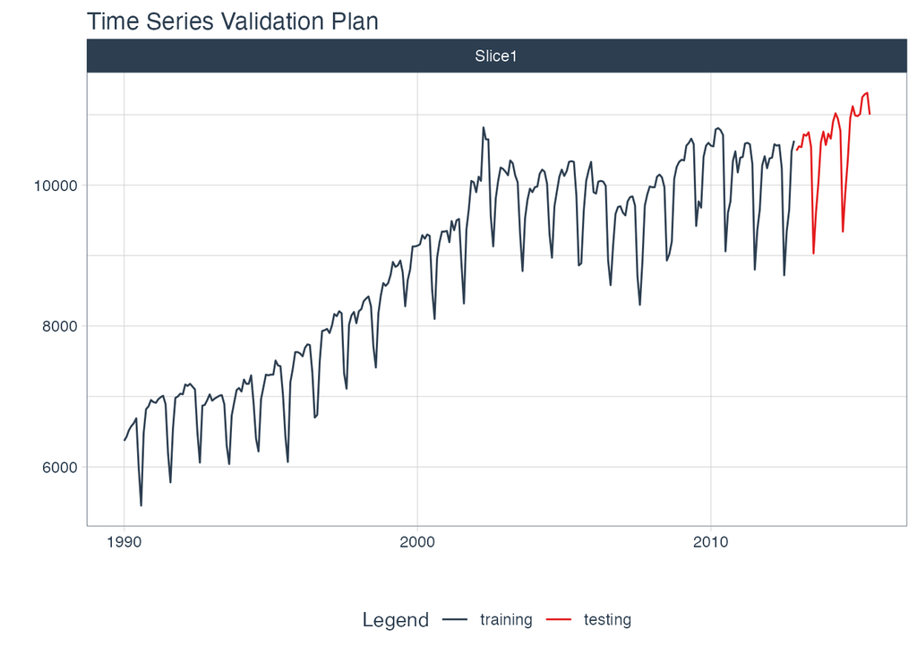

```r
splits %>%
  tk_time_series_cv_plan() %>%
  plot_time_series_cv_plan(date, value, .interactive = FALSE,
                           .title = "Time Series Validation Plan")
```

データの準備が整ったので、次は、モデルを設定する。`modeltime`パッケージのメリットは複数のモデルを効率よく管理し、評価し、再学習までを一気通貫で実行できる点。ここでは基本的なARIMAモデルとFaceBookが開発したProphetモデル、Prophet Boostモデル、ランダムフォレストの4つを設定する。

```r
model_fit_arima <- arima_reg() %>%
    set_engine(engine = "auto_arima") %>%
    fit(value ~ date, data = df_train)

model_fit_prophet <- prophet_reg(seasonality_yearly = TRUE) %>%
    set_engine(engine = "prophet") %>%
    fit(value ~ date, data = df_train)

list(model_fit_arima, model_fit_prophet)
```

```
## [[1]]
## parsnip model object
##
## Series: outcome
## ARIMA(0,1,1)(0,1,1)[12]
##
## Coefficients:
##           ma1     sma1
##       -0.3405  -0.4781
## s.e.   0.0652   0.0628
##
## sigma^2 = 25114:  log likelihood = -1699.55
## AIC=3405.1   AICc=3405.19   BIC=3415.8
##
## [[2]]
## parsnip model object
##
## PROPHET Model
## - growth: 'linear'
## - n.changepoints: 25
## - changepoint.range: 0.8
## - yearly.seasonality: 'TRUE'
## - weekly.seasonality: 'auto'
## - daily.seasonality: 'auto'
## - seasonality.mode: 'additive'
## - changepoint.prior.scale: 0.05
## - seasonality.prior.scale: 10
## - holidays.prior.scale: 10
## - logistic_cap: NULL
## - logistic_floor: NULL
## - extra_regressors: 0
```

機械学習モデルは、`tidymodels`パッケージの流れでレシピやワークフローを利用できる。

```r
recipe <- recipe(value ~ date, df_train) %>%
  step_timeseries_signature(date) %>%
  step_rm(
    contains("am.pm"),
    contains("hour"),
    contains("minute"),
    contains("second"),
    contains("xts")
  ) %>%
  step_fourier(date, period = 365, K = 5) %>%
  step_dummy(all_nominal())

recipe %>% prep() %>% bake(df_train)
```

```
## # A tibble: 275 × 47
##    date       value date_index…¹ date_…² date_…³ date_…⁴ date_…⁵ date_…⁶ date_…⁷
##    <date>     <dbl>        <dbl>   <int>   <int>   <int>   <int>   <int>   <int>
##  1 1990-01-01  6370    631152000    1990    1990       1       1       1       1
##  2 1990-02-01  6430    633830400    1990    1990       1       1       2       1
##  3 1990-03-01  6520    636249600    1990    1990       1       1       3       1
##  4 1990-04-01  6580    638928000    1990    1990       1       2       4       1
##  5 1990-05-01  6620    641520000    1990    1990       1       2       5       1
##  6 1990-06-01  6690    644198400    1990    1990       1       2       6       1
##  7 1990-07-01  6000    646790400    1990    1990       2       3       7       1
##  8 1990-08-01  5450    649468800    1990    1990       2       3       8       1
##  9 1990-09-01  6480    652147200    1990    1990       2       3       9       1
## 10 1990-10-01  6820    654739200    1990    1990       2       4      10       1
## # … with 265 more rows, 38 more variables: date_wday <int>, date_mday <int>,
## #   date_qday <int>, date_yday <int>, date_mweek <int>, date_week <int>,
## #   date_week.iso <int>, date_week2 <int>, date_week3 <int>, date_week4 <int>,
## #   date_mday7 <int>, date_sin365_K1 <dbl>, date_cos365_K1 <dbl>,
## #   date_sin365_K2 <dbl>, date_cos365_K2 <dbl>, date_sin365_K3 <dbl>,
## #   date_cos365_K3 <dbl>, date_sin365_K4 <dbl>, date_cos365_K4 <dbl>,
## #   date_sin365_K5 <dbl>, date_cos365_K5 <dbl>, date_month.lbl_01 <dbl>, …
```

レシピが完成したら、ワークフローを使ってフィッティングしておく。機械学習アルゴリズムは通常、日付・日時を処理する方法を知らないため、日付列を削除する必要がある。

```r
model_randomforest <- rand_forest(trees = 1000, min_n = 50, mtry = 15) %>%
  set_engine("ranger") %>%
  set_mode("regression")

model_fit_randomforest <- workflow() %>%
  add_model(model_randomforest) %>%
  add_recipe(recipe %>% step_rm(date)) %>%
  fit(df_train)

model_fit_randomforest
```

```
## ══ Workflow [trained] ══════════════════════════════════════════════════════════
## Preprocessor: Recipe
## Model: rand_forest()
##
## ── Preprocessor ────────────────────────────────────────────────────────────────
## 5 Recipe Steps
##
## • step_timeseries_signature()
## • step_rm()
## • step_fourier()
## • step_dummy()
## • step_rm()
##
## ── Model ───────────────────────────────────────────────────────────────────────
## Ranger result
##
## Call:
##  ranger::ranger(x = maybe_data_frame(x), y = y, mtry = min_cols(~15,      x), num.trees = ~1000, min.node.size = min_rows(~50, x),      num.threads = 1, verbose = FALSE, seed = sample.int(10^5,          1))
##
## Type:                             Regression
## Number of trees:                  1000
## Sample size:                      275
## Number of independent variables:  45
## Mtry:                             15
## Target node size:                 50
## Variable importance mode:         none
## Splitrule:                        variance
## OOB prediction error (MSE):       93416.05
## R squared (OOB):                  0.9529785
```

最後にProphet Boostモデルのフィッティングを行なう。

```r
model_prophet_boost <- prophet_boost(seasonality_yearly = TRUE) %>%
  set_engine("prophet_xgboost")

model_fit_prophet_boost <- workflow() %>%
  add_model(model_prophet_boost) %>%
  add_recipe(recipe) %>%
  fit(df_train)

model_fit_prophet_boost
```

```
## ══ Workflow [trained] ══════════════════════════════════════════════════════════
## Preprocessor: Recipe
## Model: prophet_boost()
##
## ── Preprocessor ────────────────────────────────────────────────────────────────
## 4 Recipe Steps
##
## • step_timeseries_signature()
## • step_rm()
## • step_fourier()
## • step_dummy()
##
## ── Model ───────────────────────────────────────────────────────────────────────
## PROPHET w/ XGBoost Errors
## ---
## Model 1: PROPHET
##  - growth: 'linear'
##  - n.changepoints: 25
##  - changepoint.range: 0.8
##  - yearly.seasonality: 'TRUE'
##  - weekly.seasonality: 'auto'
##  - daily.seasonality: 'auto'
##  - seasonality.mode: 'additive'
##  - changepoint.prior.scale: 0.05
##  - seasonality.prior.scale: 10
##  - holidays.prior.scale: 10
##  - logistic_cap: NULL
##  - logistic_floor: NULL
##
## ---
## Model 2: XGBoost Errors
##
## xgboost::xgb.train(params = list(eta = 0.3, max_depth = 6, gamma = 0,
##     colsample_bytree = 1, colsample_bynode = 1, min_child_weight = 1,
##     subsample = 1), data = x$data, nrounds = 15, watchlist = x$watchlist,
##     verbose = 0, objective = "reg:squarederror", nthread = 1)
```

モデルのフィッティングが完了したらモデルテーブルに追加する(`modeltime_table`関数)。これは、予測ワークフローの一部として使用されるため、必要な手順である。

```r
models_tbl <- modeltime_table(
    model_fit_arima,
    model_fit_prophet,
    model_fit_prophet_boost,
    model_fit_randomforest
)
models_tbl
```

```
## # Modeltime Table
## # A tibble: 4 × 3
##   .model_id .model     .model_desc
##       <int> <list>     <chr>
## 1         1 <fit[+]>   ARIMA(0,1,1)(0,1,1)[12]
## 2         2 <fit[+]>   PROPHET
## 3         3 <workflow> PROPHET W/ XGBOOST ERRORS
## 4         4 <workflow> RANGER
```

モデルテーブルにモデルを登録したら、テストデータでモデルを検証する。これは`modeltime_calibrate`関数で行なうことができる。

```r
calibration_tbl <- models_tbl %>%
    modeltime_calibrate(new_data = df_test)

calibration_tbl
```

```
## # Modeltime Table
## # A tibble: 4 × 5
##   .model_id .model     .model_desc               .type .calibration_data
##       <int> <list>     <chr>                     <chr> <list>
## 1         1 <fit[+]>   ARIMA(0,1,1)(0,1,1)[12]   Test  <tibble [31 × 4]>
## 2         2 <fit[+]>   PROPHET                   Test  <tibble [31 × 4]>
## 3         3 <workflow> PROPHET W/ XGBOOST ERRORS Test  <tibble [31 × 4]>
## 4         4 <workflow> RANGER                    Test  <tibble [31 × 4]>
```

これを実行すると、テストデータの観測値とモデルの予測値と残差が記録される。

```r
# ARIMA Model
calibration_tbl %>%
  pluck(".calibration_data", 1)
```

```
## # A tibble: 31 × 4
##    date       .actual .prediction .residuals
##    <date>       <dbl>       <dbl>      <dbl>
##  1 2012-12-01   10490      10449.       41.5
##  2 2013-01-01   10550      10567.      -16.5
##  3 2013-02-01   10540      10572.      -32.1
##  4 2013-03-01   10720      10768.      -47.9
##  5 2013-04-01   10700      10767.      -66.6
##  6 2013-05-01   10750      10765.      -15.4
##  7 2013-06-01   10540      10503.       37.2
##  8 2013-07-01    9030       9019.       10.8
##  9 2013-08-01    9620       9562.       58.0
## 10 2013-09-01   10050       9831.      219.
## # … with 21 more rows
```

テストデータでの精度評価を行なう。これは`modeltime_forecast`関数で行える。`modeltime_forecast`関数は、データセットを観測値、モデル1(ARIMA)の予測値、モデル2(prophet)の予測値、モデル3(Prophet Boost)、モデル4(RandomForest)の予測値という順でレコードを積み上げたデータフレームを返す。

```r
calibration_tbl %>%
    modeltime_forecast(
        new_data = df_test,
        actual_data = m750
        )
```

```
## # A tibble: 430 × 7
##    .model_id .model_desc .key   .index     .value .conf_lo .conf_hi
##        <int> <chr>       <fct>  <date>      <dbl>    <dbl>    <dbl>
##  1        NA ACTUAL      actual 1990-01-01   6370       NA       NA
##  2        NA ACTUAL      actual 1990-02-01   6430       NA       NA
##  3        NA ACTUAL      actual 1990-03-01   6520       NA       NA
##  4        NA ACTUAL      actual 1990-04-01   6580       NA       NA
##  5        NA ACTUAL      actual 1990-05-01   6620       NA       NA
##  6        NA ACTUAL      actual 1990-06-01   6690       NA       NA
##  7        NA ACTUAL      actual 1990-07-01   6000       NA       NA
##  8        NA ACTUAL      actual 1990-08-01   5450       NA       NA
##  9        NA ACTUAL      actual 1990-09-01   6480       NA       NA
## 10        NA ACTUAL      actual 1990-10-01   6820       NA       NA
## # … with 420 more rows
```

また、`plot_modeltime_forecast`関数でテストデータを可視化できる。

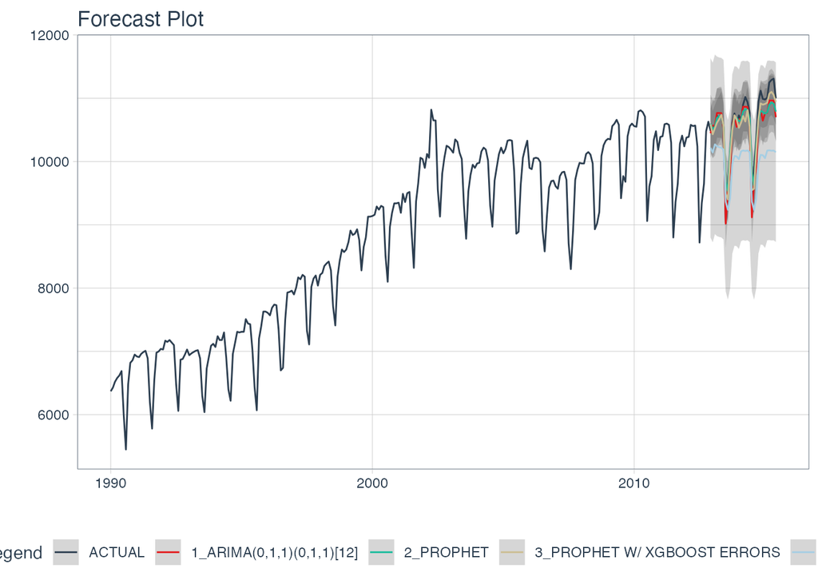

```r
calibration_tbl %>%
    modeltime_forecast(
        new_data = df_test,
        actual_data = m750
        ) %>%
    plot_modeltime_forecast(.interactive = FALSE)
```

評価指標の具体的な数値は`modeltime_accuracy`関数で計算できる。この関数は、一般的な精度指標を一気に計算できる

- `MAE`: 平均絶対誤差
- `MAPE`: 平均絶対パーセント誤差
- `MASE`: 平均絶対スケール誤差
- `SMAPE`: 対称平均絶対パーセント誤差
- `RMSE`: 2乗平均平方根誤差
- `RSQ`: R2乗

評価指標を見る限り、テストデータに対しては、Prophet Boostモデルのほうが優秀である。

```r
calibration_tbl %>%
    modeltime_accuracy() %>%
    table_modeltime_accuracy(.interactive = FALSE)
```

Accuracy Table

| .model_id | .model_desc | .type | mae | mape | mase | smape | rmse | rsq |
| --- | --- | --- | --- | --- | --- | --- | --- | --- |
| 1 | ARIMA(0,1,1)(0,1,1)[12] | Test | 151.33 | 1.41 | 0.52 | 1.43 | 197.71 | 0.93 |
| 2 | PROPHET | Test | 175.50 | 1.68 | 0.60 | 1.68 | 232.88 | 0.88 |
| 3 | PROPHET W/ XGBOOST ERRORS | Test | 148.46 | 1.42 | 0.51 | 1.43 | 185.46 | 0.92 |
| 4 | RANGER | Test | 663.03 | 6.16 | 2.26 | 6.38 | 717.87 | 0.67 |

この結果から、Prophet Boostモデルで、フルデータセットを再学習させて、将来の予測を行なうことがよいとわかる。この作業は`modeltime_refit`関数で実行できる。

この際に特定のモデルを取り出す必要はなく、モデルテーブルで管理しているモデルを使って予測できる。ここでは1年先を予測する。

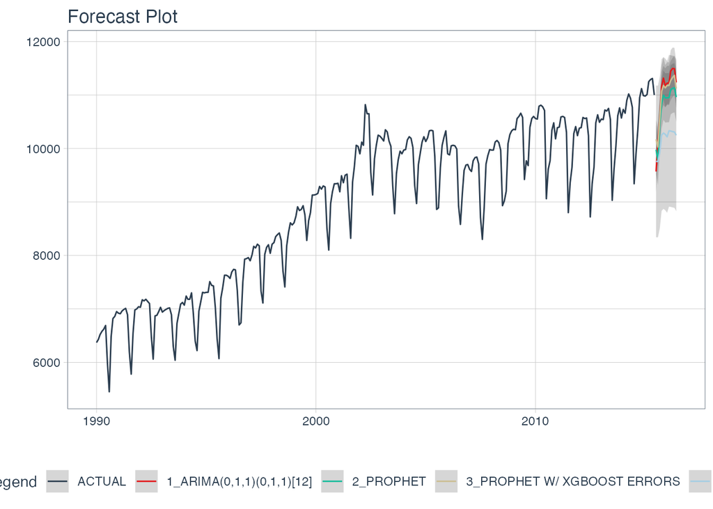

```r
refit_tbl <- calibration_tbl %>%
    modeltime_refit(data = m750)

refit_tbl %>%
    modeltime_forecast(h = "1 years", actual_data = m750) %>%
    plot_modeltime_forecast(.interactive = FALSE)
```

Prophet Boostモデルだけでよいのであれば、モデルテーブルから取り除けば良い。

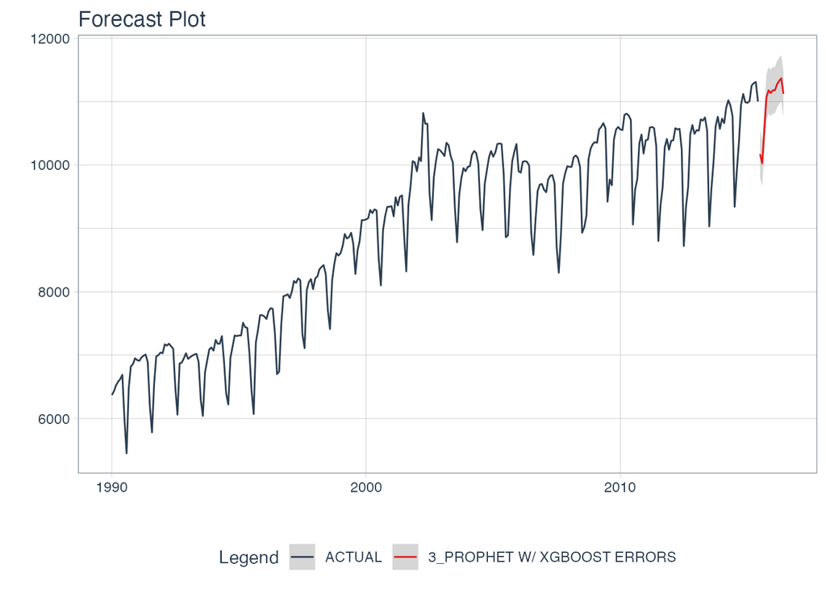

```r
refit_tbl_only_arima <- calibration_tbl %>%
    filter(.model_id == 3) %>%
    modeltime_refit(data = m750)

refit_tbl_only_arima %>%
    modeltime_forecast(h = "1 years", actual_data = m750) %>%
    plot_modeltime_forecast(.interactive = FALSE)
```

以上が`modeltime`パッケージの基本的な使い方である。

予測値のデータフレームを参考までに全件出力しておく。

```r
refit_tbl %>%
    modeltime_forecast(h = "1 years", actual_data = m750) %>%
    print(n = 500)
```

```
## # A tibble: 354 × 7
##     .model_id .model_desc               .key   .index     .value .conf…¹ .conf…²
##         <int> <chr>                     <fct>  <date>      <dbl>   <dbl>   <dbl>
##   1        NA ACTUAL                    actual 1990-01-01  6370      NA      NA
##   2        NA ACTUAL                    actual 1990-02-01  6430      NA      NA
##   3        NA ACTUAL                    actual 1990-03-01  6520      NA      NA
##   4        NA ACTUAL                    actual 1990-04-01  6580      NA      NA
##   5        NA ACTUAL                    actual 1990-05-01  6620      NA      NA
##   6        NA ACTUAL                    actual 1990-06-01  6690      NA      NA
##   7        NA ACTUAL                    actual 1990-07-01  6000      NA      NA
##   8        NA ACTUAL                    actual 1990-08-01  5450      NA      NA
##   9        NA ACTUAL                    actual 1990-09-01  6480      NA      NA
##  10        NA ACTUAL                    actual 1990-10-01  6820      NA      NA
##  11        NA ACTUAL                    actual 1990-11-01  6860      NA      NA
##  12        NA ACTUAL                    actual 1990-12-01  6950      NA      NA
```

[output cut: 343 more lines]

## 参考文献

- [Tidymodels](https://www.tidymodels.org/)
- [Tidy Modeling with R](https://www.tmwr.org/software-modeling.html)